# Project_Regression

Lukasz Marchel

27 12 2020

## Problem Analyzed

The dataset on which this project is based on contains information on the game “Fifa 19”. It is a football game with players taken from real life. Each player is assigned an overall rank ( 0-99) Moreover, each player is graded based on a set of skills. Each of these skills is also ranked from 0 -99. All players in the game are ranked by the same skills. The aim of this project is to create a model which could predict the overall rank of a player based on the ranks of each particular skill and to find out which skills have a larger impact than others (if any). A regression model was estimated as the target variable, Overall rank, is continuous.

## Initial data Analysis

```r
data <- read.csv2("ml2_data_regression.csv")

glimpse(data)
```

```
## Rows: 18,207
## Columns: 35
## $ X               <int> 0, 1, 2, 3, 4, 5, 6, 7, 8, 9, 10, 11, 12, 13, 14, 1...
## $ ID              <int> 158023, 20801, 190871, 193080, 192985, 183277, 1770...
## $ Name            <chr> "L. Messi", "Cristiano Ronaldo", "Neymar Jr", "De G...
## $ Age             <int> 31, 33, 26, 27, 27, 27, 32, 31, 32, 25, 29, 28, 32,...
## $ Overall         <int> 94, 94, 92, 91, 91, 91, 91, 91, 91, 90, 90, 90, 90,...
## $ Position        <chr> "RF", "ST", "LW", "GK", "RCM", "LF", "RCM", "RS", "...
## $ Crossing        <int> 84, 84, 79, 17, 93, 81, 86, 77, 66, 13, 62, 88, 55,...
## $ Finishing       <int> 95, 94, 87, 13, 82, 84, 72, 93, 60, 11, 91, 76, 42,...
## $ HeadingAccuracy <int> 70, 89, 62, 21, 55, 61, 55, 77, 91, 15, 85, 54, 92,...
## $ ShortPassing    <int> 90, 81, 84, 50, 92, 89, 93, 82, 78, 29, 83, 92, 79,...
## $ Volleys         <int> 86, 87, 84, 13, 82, 80, 76, 88, 66, 13, 89, 82, 47,...
## $ Dribbling       <int> 97, 88, 96, 18, 86, 95, 90, 87, 63, 12, 85, 81, 53,...
## $ Curve           <int> 93, 81, 88, 21, 85, 83, 85, 86, 74, 13, 77, 86, 49,...
```

[output cut: 22 more lines]

There are 35 columns and 18,207 observations (players). Not all columns however, can be used as variables (they are not skills).

```r
summary(data)
```

```
##        X               ID             Name                Age
##  Min.   :    0   Min.   :    16   Length:18207       Min.   :16.00
##  1st Qu.: 4552   1st Qu.:200316   Class :character   1st Qu.:21.00
##  Median : 9103   Median :221759   Mode  :character   Median :25.00
##  Mean   : 9103   Mean   :214298                      Mean   :25.12
##  3rd Qu.:13654   3rd Qu.:236530                      3rd Qu.:28.00
##  Max.   :18206   Max.   :246620                      Max.   :45.00
##
##     Overall        Position            Crossing       Finishing
##  Min.   :46.00   Length:18207       Min.   : 5.00   Min.   : 2.00
##  1st Qu.:62.00   Class :character   1st Qu.:38.00   1st Qu.:30.00
##  Median :66.00   Mode  :character   Median :54.00   Median :49.00
##  Mean   :66.24                      Mean   :49.74   Mean   :45.56
##  3rd Qu.:71.00                      3rd Qu.:64.00   3rd Qu.:62.00
##  Max.   :94.00                      Max.   :93.00   Max.   :95.00
##                                     NA's   :76      NA's   :76
##  HeadingAccuracy  ShortPassing      Volleys        Dribbling
##  Min.   : 4.0    Min.   : 7.00   Min.   : 4.00   Min.   : 4.00
##  1st Qu.:45.0    1st Qu.:54.00   1st Qu.:30.00   1st Qu.:49.00
##  Median :56.0    Median :62.00   Median :44.00   Median :61.00
##  Mean   :52.3    Mean   :58.69   Mean   :42.92   Mean   :55.38
##  3rd Qu.:64.0    3rd Qu.:68.00   3rd Qu.:57.00   3rd Qu.:68.00
##  Max.   :94.0    Max.   :93.00   Max.   :90.00   Max.   :97.00
##  NA's   :76      NA's   :76      NA's   :76      NA's   :76
##      Curve         FKAccuracy     LongPassing     BallControl
##  Min.   : 6.00   Min.   : 3.00   Min.   : 9.00   Min.   : 5.00
##  1st Qu.:34.00   1st Qu.:31.00   1st Qu.:43.00   1st Qu.:54.00
##  Median :48.00   Median :41.00   Median :56.00   Median :63.00
##  Mean   :47.18   Mean   :42.87   Mean   :52.72   Mean   :58.38
##  3rd Qu.:62.00   3rd Qu.:57.00   3rd Qu.:64.00   3rd Qu.:69.00
##  Max.   :94.00   Max.   :94.00   Max.   :93.00   Max.   :96.00
##  NA's   :76      NA's   :76      NA's   :76      NA's   :76
##   Acceleration    SprintSpeed       Agility       Reactions        Balance
##  Min.   :12.00   Min.   :12.00   Min.   :14.0   Min.   :21.00   Min.   :16.00
##  1st Qu.:57.00   1st Qu.:57.00   1st Qu.:55.0   1st Qu.:56.00   1st Qu.:56.00
##  Median :67.00   Median :67.00   Median :66.0   Median :62.00   Median :66.00
##  Mean   :64.61   Mean   :64.73   Mean   :63.5   Mean   :61.84   Mean   :63.96
##  3rd Qu.:75.00   3rd Qu.:75.00   3rd Qu.:74.0   3rd Qu.:68.00   3rd Qu.:74.00
##  Max.   :97.00   Max.   :96.00   Max.   :96.0   Max.   :96.00   Max.   :96.00
##  NA's   :76      NA's   :76      NA's   :76     NA's   :76      NA's   :76
```

[output cut: 9 more lines]

```
##  Min.   : 3.00   Min.   :11.00   Min.   : 3.0   Min.   : 2.00   Min.   :10.00
##  1st Qu.:33.00   1st Qu.:44.00   1st Qu.:26.0   1st Qu.:38.00   1st Qu.:44.00
##  Median :51.00   Median :59.00   Median :52.0   Median :55.00   Median :55.00
##  Mean   :47.12   Mean   :55.87   Mean   :46.7   Mean   :49.97   Mean   :53.41
##  3rd Qu.:62.00   3rd Qu.:69.00   3rd Qu.:64.0   3rd Qu.:64.00   3rd Qu.:64.00
##  Max.   :94.00   Max.   :95.00   Max.   :92.0   Max.   :95.00   Max.   :94.00
##  NA's   :76      NA's   :76      NA's   :76     NA's   :76      NA's   :76
##    Penalties       Composure        Marking      StandingTackle SlidingTackle
##  Min.   : 5.00   Min.   : 3.00   Min.   : 3.00   Min.   : 2.0   Min.   : 3.00
##  1st Qu.:39.00   1st Qu.:51.00   1st Qu.:30.00   1st Qu.:27.0   1st Qu.:24.00
##  Median :49.00   Median :60.00   Median :53.00   Median :55.0   Median :52.00
##  Mean   :48.56   Mean   :58.66   Mean   :47.28   Mean   :47.7   Mean   :45.66
##  3rd Qu.:60.00   3rd Qu.:67.00   3rd Qu.:64.00   3rd Qu.:66.0   3rd Qu.:64.00
##  Max.   :92.00   Max.   :96.00   Max.   :94.00   Max.   :93.0   Max.   :91.00
##  NA's   :76      NA's   :76      NA's   :76      NA's   :76     NA's   :76
```

After summarizing the data, we can see that most variables have 76 missing values. After checking, these 76 values are missing for the same observations for all variables. Hence, they will later be removed for the dataset.

```r
describe(data)
```

```
## data
##
##  35  Variables      18207  Observations
## --------------------------------------------------------------------------------
## X
##        n  missing distinct     Info     Mean      Gmd      .05      .10
##    18207        0    18207        1     9103     6069    910.3   1820.6
##      .25      .50      .75      .90      .95
##   4551.5   9103.0  13654.5  16385.4  17295.7
##
## lowest :     0     1     2     3     4, highest: 18202 18203 18204 18205 18206
## --------------------------------------------------------------------------------
## ID
##        n  missing distinct     Info     Mean      Gmd      .05      .10
##    18207        0    18207        1   214298    30098   163964   179805
##      .25      .50      .75      .90      .95
##   200316   221759   236530   243215   244736
##
## lowest :     16     41     80    164    657, highest: 246609 246613 246616 246617 246620
## --------------------------------------------------------------------------------
## Name
##        n  missing distinct
##    18207        0    17194
##
## lowest : ?¤igo L¢pez    ?caro          ?lex Barrera   ?lex Blanco    ?lex Centelles
## highest: Zhu Zhengyu    Zou Zheng      Zubeldia       Zubiaurre      Zuo Yiteng
## --------------------------------------------------------------------------------
## Age
##        n  missing distinct     Info     Mean      Gmd      .05      .10
##    18207        0       29    0.996    25.12    5.305       18       19
##      .25      .50      .75      .90      .95
##       21       25       28       32       33
##
## lowest : 16 17 18 19 20, highest: 40 41 42 44 45
## --------------------------------------------------------------------------------
## Overall
##        n  missing distinct     Info     Mean      Gmd      .05      .10
##    18207        0       48    0.998    66.24    7.761       54       57
##      .25      .50      .75      .90      .95
##       62       66       71       75       77
```

[output cut: 226 more lines]

```
##        n  missing distinct     Info     Mean      Gmd      .05      .10
##    18131       76       90        1     47.7    24.59       13       15
##      .25      .50      .75      .90      .95
##       27       55       66       72       75
##
## lowest :  2  5  6  7  8, highest: 89 90 91 92 93
## --------------------------------------------------------------------------------
## SlidingTackle
##        n  missing distinct     Info     Mean      Gmd      .05      .10
##    18131       76       88        1    45.66    24.23       12       15
##      .25      .50      .75      .90      .95
##       24       52       64       70       74
##
## lowest :  3  4  6  7  8, highest: 87 88 89 90 91
## --------------------------------------------------------------------------------
```

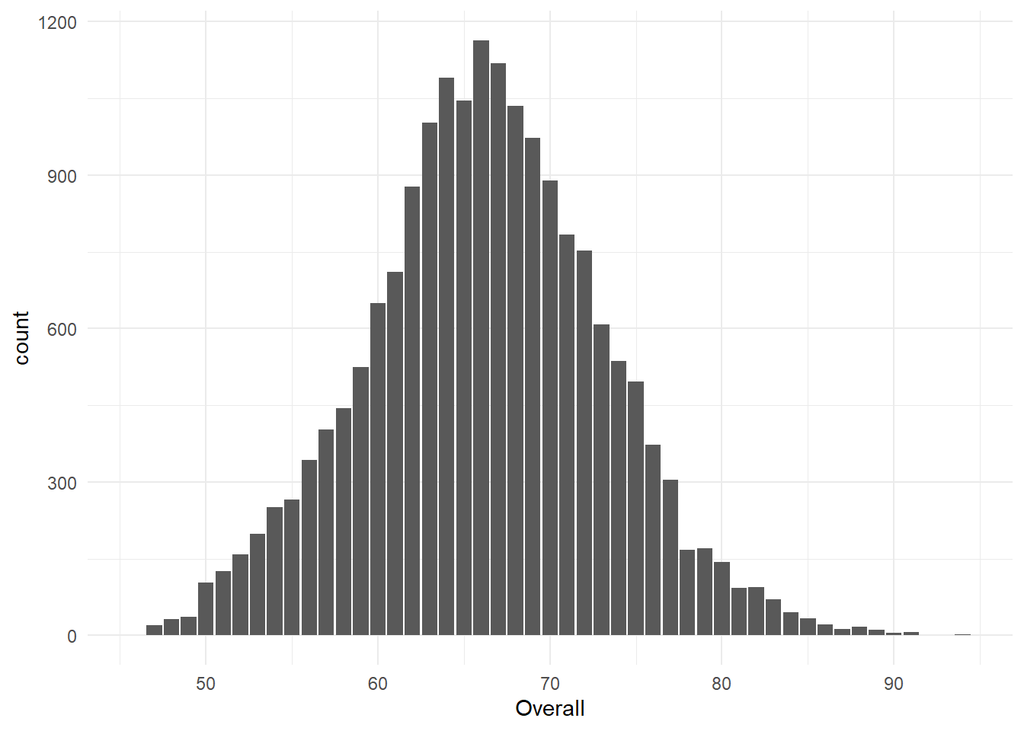

After plotting the distribution of the target variable, we can see that, it clearly resembles a normal distribution.

## Data Preparation

In order to prepare the data for for modelling, we need to remove the columns which are not skills. We also omit the observations with missing data (76 players total).

```r
data <- data.frame(data)

data <- data[, -c(1, 2, 3, 6)]

data <- na.omit(data)
```

Next, a correlation matrix was created in order to check the correlation between variables to see if any should be removed, however none were.

```r
res2 <- rcorr(as.matrix(data[, -2]))
res2$P
```

[output not shown]

Decision Tree

As the first model, a simple decision tree was created. First, however, the dataset had to be split into a training and testing sample. The proprtions chosen were 70/30. All predictors were used in the formula.

```
##
## Regression tree:
## tree(formula = model1.formula, data = data)
## Variables actually used in tree construction:
## [1] "Reactions"      "BallControl"    "StandingTackle"
## Number of terminal nodes:  11
## Residual mean deviance:  10.9 = 197500 / 18120
## Distribution of residuals:
##      Min.   1st Qu.    Median      Mean   3rd Qu.      Max.
## -18.06000  -2.06500   0.01233   0.00000   2.01200  17.07000
```

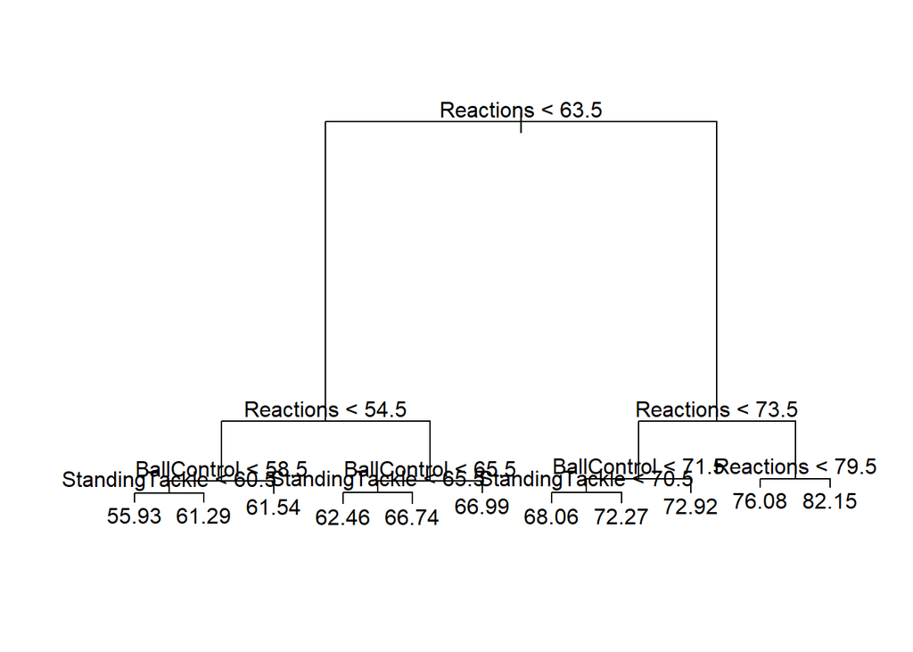

Cross Validation

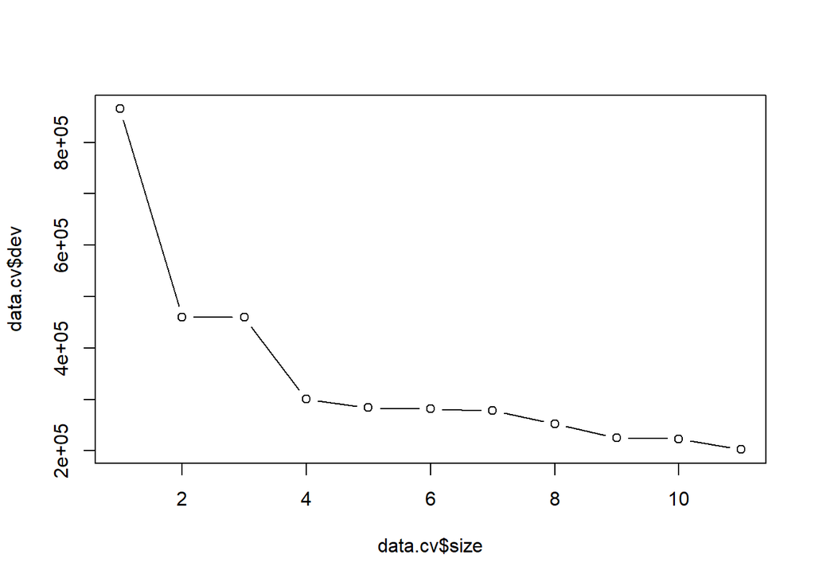

Next we prune the tree.

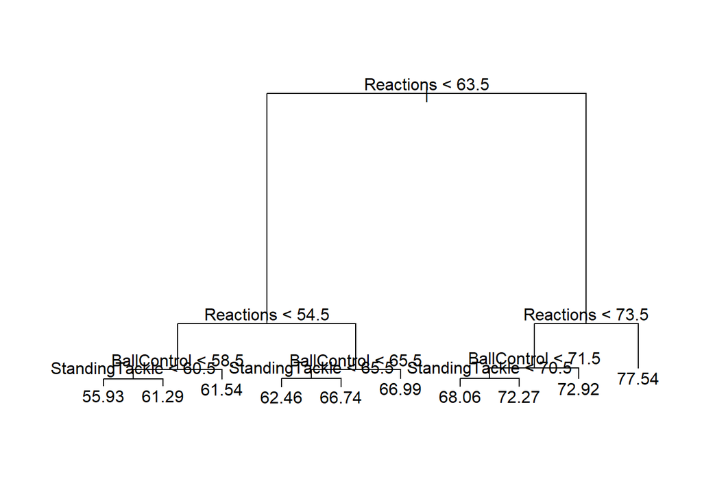

```r
data.tree1 <- prune.tree(data.tree, best = 10)
plot(data.tree1)
text(data.tree1, pretty = 0)
```

Now we can make predictions.

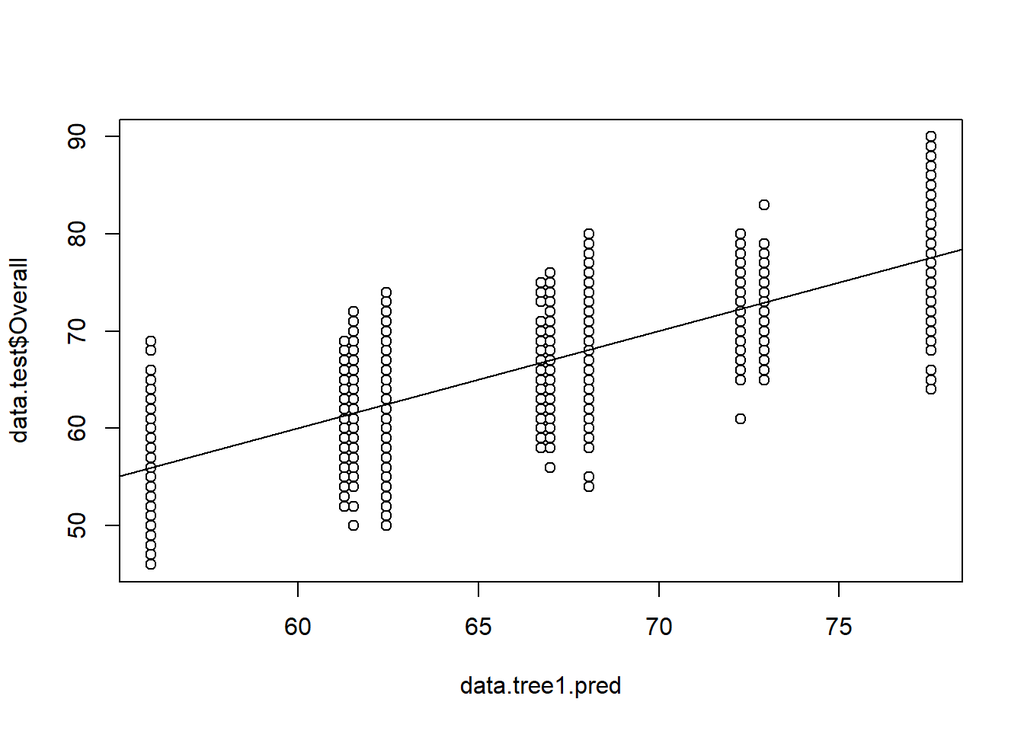

Calculating the mean square of prediciton error

```r
mean((data.tree1.pred - data.test$Overall) ^ 2)
```

```
## [1] 11.33163
```

We can calculate the mean square prediction error of the first tree and compare

```
## [1] 10.65702
```

Simple linear model and its mean square prediction error

```
## [1] 9.583085
```

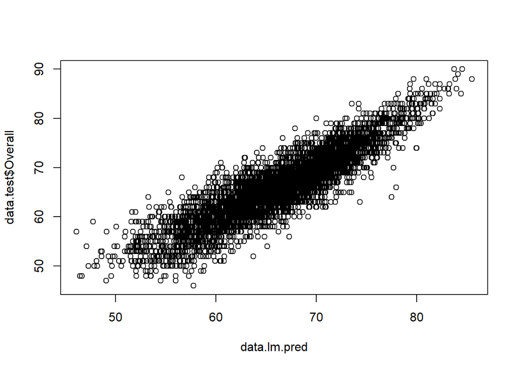

```r
plot(data.lm.pred, data.test$Overall)
```

It looks like the the simple linear regression actually has the lowest prediction error.

Random Forest Model

Creating a regular random forest model from which we can see that the optimal number of trees is around 100.

```r
set.seed(123456789)
data.rf <- randomForest(model1.formula,
                           data = data.train)

print(data.rf)
```

```
##
## Call:
##  randomForest(formula = model1.formula, data = data.train)
##                Type of random forest: regression
##                      Number of trees: 500
## No. of variables tried at each split: 10
##
##           Mean of squared residuals: 2.810948
##                     % Var explained: 94.14
```

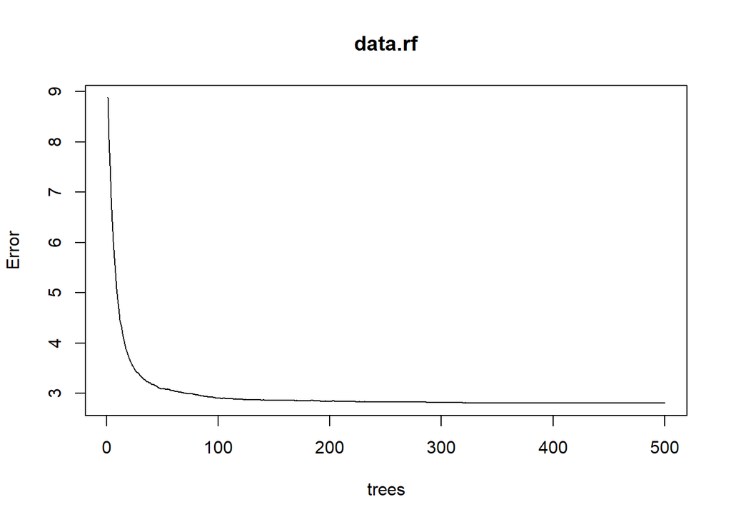

```r
plot(data.rf)
```

Creating the random forest with 100 trees.

```r
data.rf2 <-
  randomForest(model1.formula,
               data = data.train,
               ntree = 100,
               sampsize = nrow(data.train),
               mtry = 10,
               nodesize = 100,
               importance = TRUE)
print(data.rf2)
```

```
##
## Call:
##  randomForest(formula = model1.formula, data = data.train, ntree = 100,      sampsize = nrow(data.train), mtry = 10, nodesize = 100, importance = TRUE)
##                Type of random forest: regression
##                      Number of trees: 100
## No. of variables tried at each split: 10
##
##           Mean of squared residuals: 3.616953
##                     % Var explained: 92.46
```

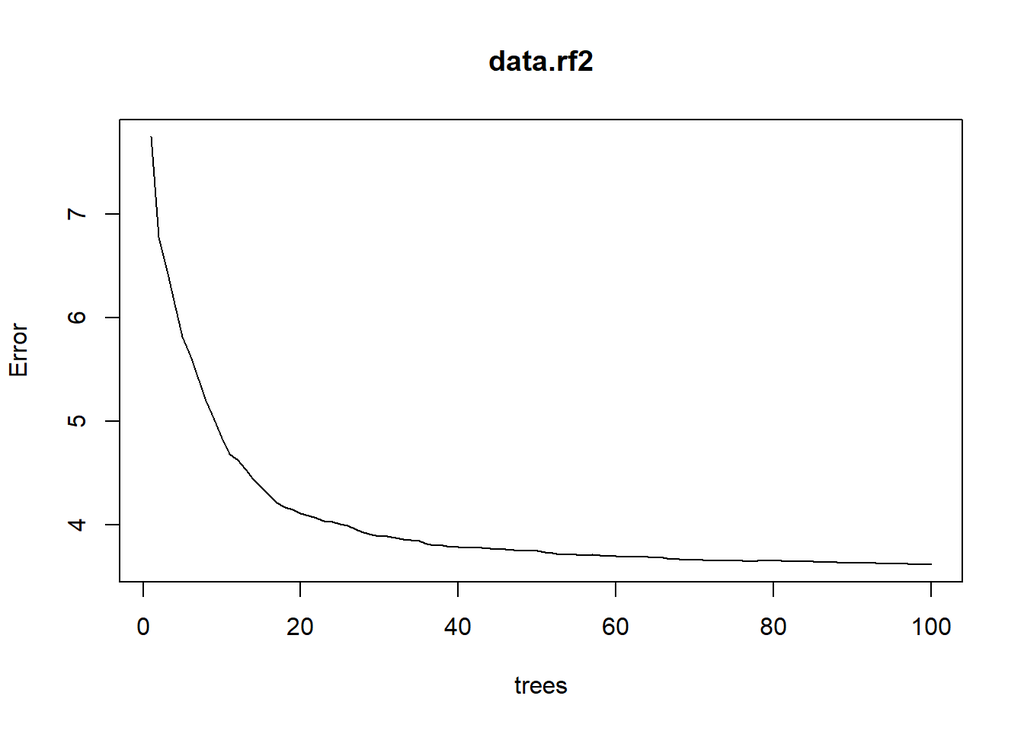

```r
plot(data.rf2)
```

Cross validation of the random tree.

```r
parameters_rf <- expand.grid(mtry = 2:10)
ctrl_cv1 <- trainControl(method = "cv")

set.seed(123456789)
data.rf3 <- train(model1.formula,
        data = data.train,
        method = "rf",
        ntree = 100,
        nodesize = 100,
        Tunegrid = parameters_rf,
        trControl = ctrl_cv1,
        importance = TRUE)
```

In the end mtry = 15 was used (optimal because the RMSE is the lowest, calculated automatically)

```
## Random Forest
##
## 12693 samples
##    30 predictor
##
## No pre-processing
## Resampling: Cross-Validated (10 fold)
## Summary of sample sizes: 11424, 11423, 11423, 11424, 11425, 11424, ...
## Resampling results across tuning parameters:
##
##   mtry  RMSE      Rsquared   MAE
##    2    2.173373  0.9189636  1.506737
##   15    1.967417  0.9217107  1.427817
##   29    2.076360  0.9111192  1.512672
##
## RMSE was used to select the optimal model using the smallest value.
## The final value used for the model was mtry = 15.
```

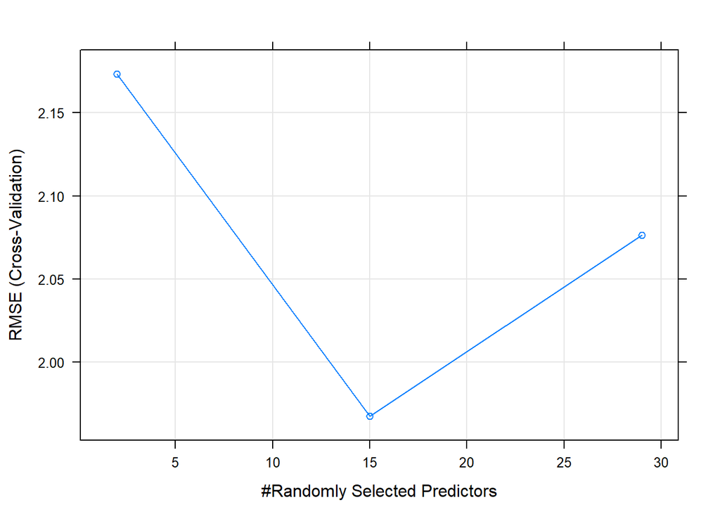

Calculating the predictions and prediction errors of the random trees

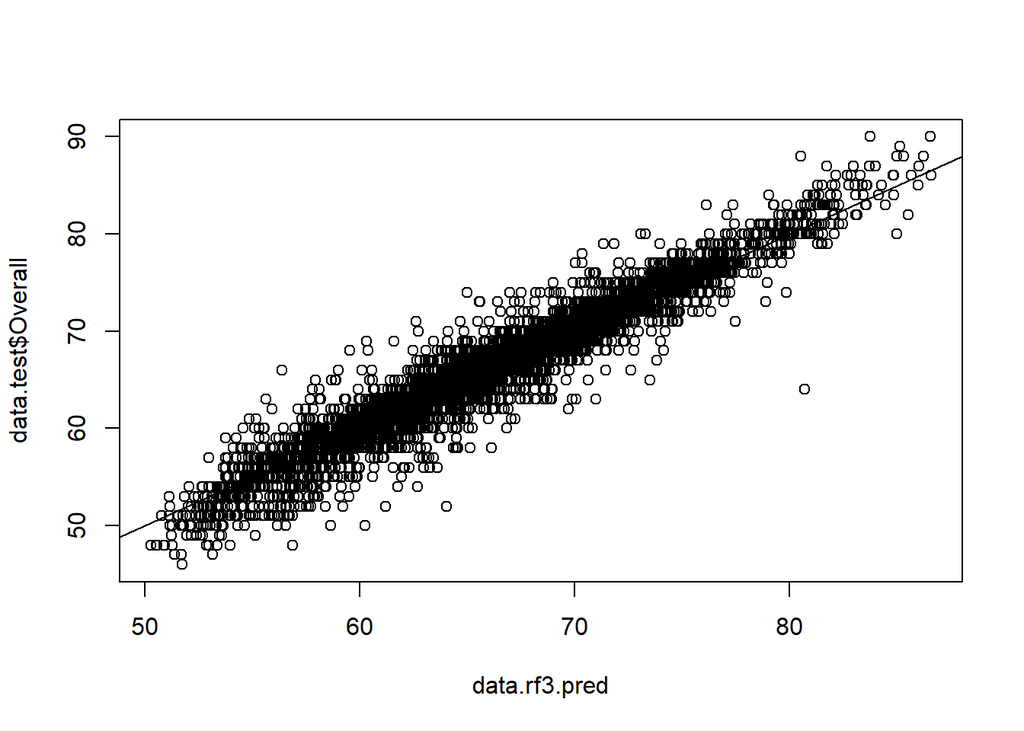

```r
data.rf3.pred <- predict(data.rf3, newdata = data.test)
plot(data.rf3.pred, data.test$Overall)
abline(0, 1)
```

```r
mean((data.rf3.pred - data.test$Overall) ^ 2)
```

```
## [1] 3.70115
```

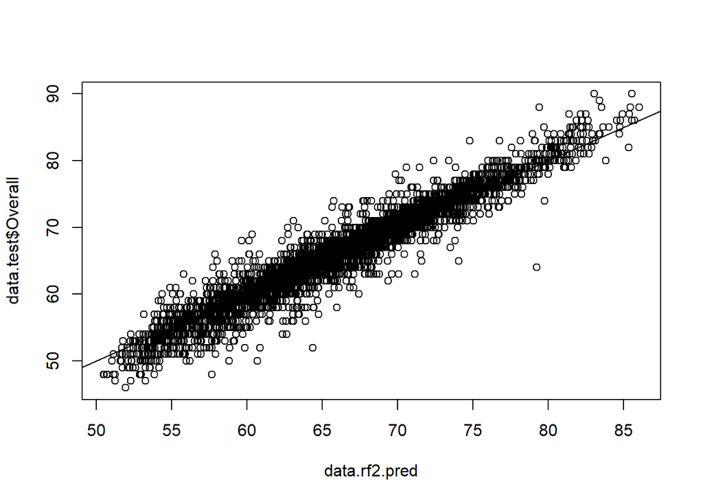

```r
data.rf2.pred <- predict(data.rf2, newdata = data.test)
plot(data.rf2.pred, data.test$Overall)
abline(0, 1)
```

```r
mean((data.rf2.pred - data.test$Overall) ^ 2)
```

```
## [1] 3.455979
```

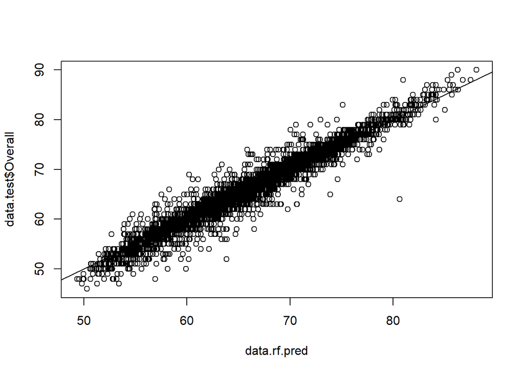

```r
data.rf.pred <- predict(data.rf, newdata = data.test)
plot(data.rf.pred, data.test$Overall)
abline(0, 1)
```

```r
mean((data.rf.pred - data.test$Overall) ^ 2)
```

```
## [1] 2.77165
```

Random Forest results:

data.rf3 is best because it is cross-validated. The Mean Square Error of the cross validated model is actually the highest among the random forest models. However, it in general is a less biased (or optimistic) estimate of the model skill than of a simple train/test split.

Boosting

Training the model with gbm with arbitrary values.

```r
model3.formula <- Overall ~ .
set.seed(123456789)
data.gbm <-
  gbm(model3.formula,
      data = data.train,
      distribution = "gaussian",
      # total number of trees
      n.trees = 500,
      # number of variable interactions - actually depth of the trees
      interaction.depth = 4,
      # shrinkage parameter - speed (pace) of learning
      shrinkage = 0.01,
      verbose = FALSE)
```

Generating a prediction on the dataset.

```r
data.pred.test.gbm <- predict(data.gbm,
                                 data.test,
                                 n.trees = 500)
```

Tuning of parameters

```r
modelLookup("gbm")
```

```
##   model         parameter                   label forReg forClass probModel
## 1   gbm           n.trees   # Boosting Iterations   TRUE     TRUE      TRUE
## 2   gbm interaction.depth          Max Tree Depth   TRUE     TRUE      TRUE
## 3   gbm         shrinkage               Shrinkage   TRUE     TRUE      TRUE
## 4   gbm    n.minobsinnode Min. Terminal Node Size   TRUE     TRUE      TRUE
```

```r
parameters_gbm <- expand.grid(interaction.depth = c(1, 2, 4),
                              n.trees = c(100, 500),
                              shrinkage = c(0.01, 0.1),
                              n.minobsinnode = c(100, 250, 500))
ctrl_cv3 <- trainControl(method = "cv",
                         number = 3)


  set.seed(123456789)
  data.gbm2  <- train(model3.formula,
                         data = data.train,
                         distribution = "gaussian",
                         method = "gbm",
                         tuneGrid = parameters_gbm,
                         trControl = ctrl_cv3,
                         verbose = FALSE)
data.gbm2
```

```
## Stochastic Gradient Boosting
##
## 12693 samples
##    30 predictor
##
## No pre-processing
## Resampling: Cross-Validated (3 fold)
## Summary of sample sizes: 8462, 8462, 8462
## Resampling results across tuning parameters:
##
##   shrinkage  interaction.depth  n.minobsinnode  n.trees  RMSE      Rsquared
##   0.01       1                  100             100      4.975014  0.6860928
##   0.01       1                  100             500      3.191654  0.8059061
##   0.01       1                  250             100      4.971894  0.6850683
##   0.01       1                  250             500      3.208228  0.8023100
##   0.01       1                  500             100      4.975946  0.6854819
##   0.01       1                  500             500      3.263965  0.7918620
##   0.01       2                  100             100      4.490936  0.7483551
##   0.01       2                  100             500      2.782307  0.8443432
##   0.01       2                  250             100      4.490386  0.7464045
##   0.01       2                  250             500      2.806794  0.8412001
##   0.01       2                  500             100      4.503875  0.7416609
##   0.01       2                  500             500      2.903922  0.8289454
##   0.01       4                  100             100      4.124133  0.7983582
##   0.01       4                  100             500      2.358748  0.8856693
##   0.01       4                  250             100      4.135291  0.7943546
##   0.01       4                  250             500      2.411059  0.8807014
##   0.01       4                  500             100      4.190663  0.7777669
##   0.01       4                  500             500      2.559886  0.8651978
##   0.10       1                  100             100      2.847199  0.8332210
##   0.10       1                  100             500      2.409359  0.8790751
##   0.10       1                  250             100      2.870677  0.8303401
##   0.10       1                  250             500      2.471404  0.8727084
##   0.10       1                  500             100      2.972516  0.8178780
##   0.10       1                  500             500      2.611043  0.8579935
##   0.10       2                  100             100      2.469137  0.8733277
##   0.10       2                  100             500      1.914736  0.9237059
##   0.10       2                  250             100      2.520474  0.8681010
##   0.10       2                  250             500      1.996832  0.9170330
##   0.10       2                  500             100      2.640797  0.8551658
```

[output cut: 33 more lines]

```
##   1.375102
##   1.889383
##   1.430508
##   1.968297
##   1.558256
##   1.519761
##   1.249838
##   1.562282
##   1.268233
##   1.695068
##   1.407172
##
## RMSE was used to select the optimal model using the smallest value.
## The final values used for the model were n.trees = 500, interaction.depth =
##  4, shrinkage = 0.1 and n.minobsinnode = 100.
```

The optimal number of trees is 500.

```r
data.pred.test.gbm2 <- predict(data.gbm2,
                                    data.test,
                                    n.trees = 500)
mean((data.pred.test.gbm2 - data.test$Overall) ^ 2)
```

```
## [1] 2.896938
```

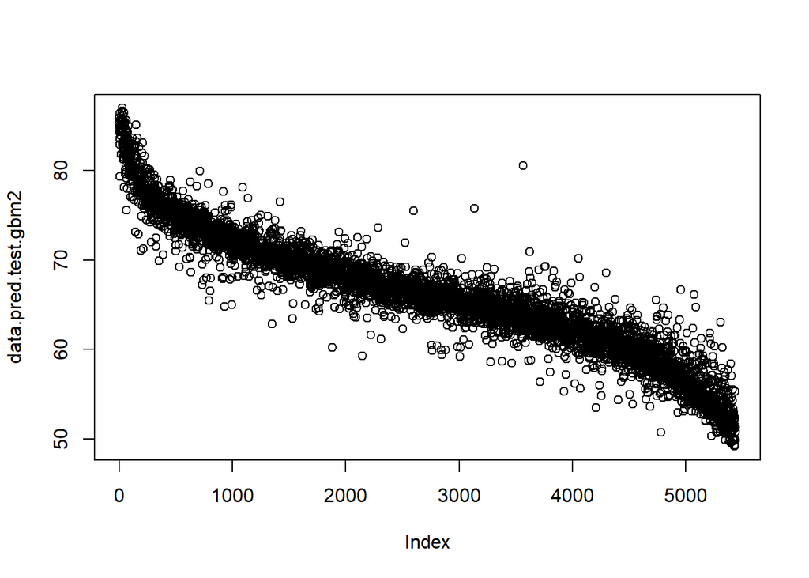

```r
plot(data.pred.test.gbm2)
```